# nkelley_OriginalHomeworkCode_05

```r
library(tidyverse)
library(curl)
library(dplyr)
```

```r
library(ggplot2)
```

```r
library(sciplot)
```

I had to remove the install packages pieces as it was making it so that I could not knit the code.

[1] Using the “KamilarAndCooperData.csv” dataset, run a linear regression looking at log(HomeRange_km2) in relation to log(Body_mass_female_mean) and report your β coeffiecients (slope and intercept).

```r
f <- curl("https://raw.githubusercontent.com/fuzzyatelin/fuzzyatelin.github.io/master/AN588_Fall21/KamilarAndCooperData.csv")
c <- read.csv(f, header = TRUE, sep = ",", stringsAsFactors = FALSE)
colnames(c)
```

```
##  [1] "Scientific_Name"         "Family"
##  [3] "Genus"                   "Species"
##  [5] "Brain_Size_Species_Mean" "Brain_Size_Female_Mean"
##  [7] "Brain_size_Ref"          "Body_mass_male_mean"
##  [9] "Body_mass_female_mean"   "Mass_Dimorphism"
## [11] "Mass_Ref"                "MeanGroupSize"
## [13] "AdultMales"              "AdultFemale"
## [15] "AdultSexRatio"           "Social_Organization_Ref"
## [17] "InterbirthInterval_d"    "Gestation"
## [19] "WeaningAge_d"            "MaxLongevity_m"
## [21] "LitterSz"                "Life_History_Ref"
## [23] "GR_MidRangeLat_dd"       "Precip_Mean_mm"
## [25] "Temp_Mean_degC"          "AET_Mean_mm"
## [27] "PET_Mean_mm"             "Climate_Ref"
## [29] "HomeRange_km2"           "HomeRangeRef"
## [31] "DayLength_km"            "DayLengthRef"
## [33] "Territoriality"          "Fruit"
## [35] "Leaves"                  "Fauna"
## [37] "DietRef1"                "Canine_Dimorphism"
## [39] "Canine_Dimorphism_Ref"   "Feed"
## [41] "Move"                    "Rest"
## [43] "Social"                  "Activity_Budget_Ref"
```

```r
#creates data frame from raw csv file
d <- select(c, Body_mass_female_mean, HomeRange_km2)
d <- na.omit(d)
summary(d)
```

```
##  Body_mass_female_mean HomeRange_km2
##  Min.   :   42.0       Min.   : 0.002
##  1st Qu.:  933.3       1st Qu.: 0.060
##  Median : 3517.9       Median : 0.290
##  Mean   : 5364.2       Mean   : 1.821
##  3rd Qu.: 6764.8       3rd Qu.: 0.958
##  Max.   :71500.0       Max.   :28.240
```

```r
x <- log(d$Body_mass_female_mean)
y <- log(d$HomeRange_km2)
m <- lm(x~y, data = d)
summary(m)
```

```
##
## Call:
## lm(formula = x ~ y, data = d)
##
## Residuals:
##      Min       1Q   Median       3Q      Max
## -2.41652 -0.68537  0.07268  0.79696  2.11649
##
## Coefficients:
##             Estimate Std. Error t value Pr(>|t|)
## (Intercept)  8.48616    0.10199   83.20   <2e-16 ***
## y            0.50638    0.04147   12.21   <2e-16 ***
## ---
## Signif. codes:  0 '***' 0.001 '**' 0.01 '*' 0.05 '.' 0.1 ' ' 1
##
## Residual standard error: 0.9949 on 135 degrees of freedom
## Multiple R-squared:  0.5248, Adjusted R-squared:  0.5213
## F-statistic: 149.1 on 1 and 135 DF,  p-value: < 2.2e-16
```

I was wondering why I got different coefficients than you, but then I realized you have the regression variables switched! I think we are meant to be doing log(HomeRange_km2) ~ log(Body_mass_female_mean)

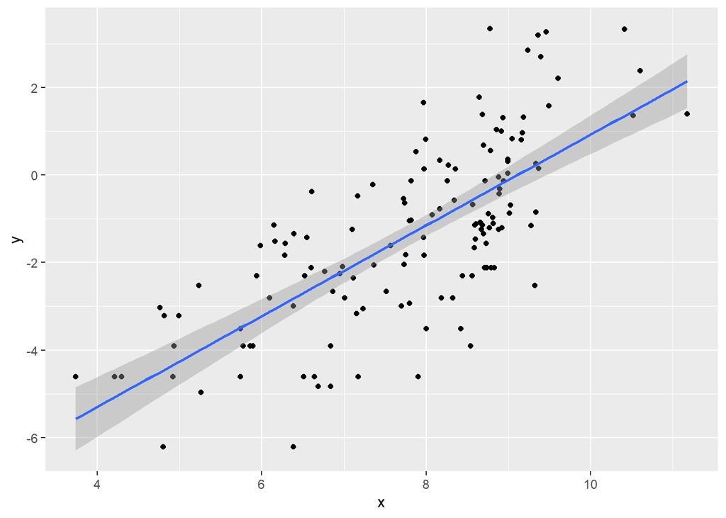

```r
g <- ggplot(data = d, aes(x = x, y = y))
g <- g + geom_point()
g <- g + geom_smooth(method = "lm", formula = y ~ x)
g
```

```r
t <- coef(summary(m))
t <- data.frame(unlist(t))
colnames(t) <- c("Est", "SE", "t", "p")
t
```

```
##                  Est         SE        t             p
## (Intercept) 8.486157 0.10199078 83.20514 7.099424e-118
## y           0.506380 0.04146927 12.21097  1.447292e-23
```

```r
#beta0 (y-intercept):
beta0 <- t$Est[1]

#beta1 (slope):
beta1 <- t$Est[2]
```

I like your code for getting the coefficients! One thing I would say is it might look better to call your code after assigning it a value, such as having “beta0” on its own after giving it its value. For an even fancier display, you can also rbind beta0 and beta1 together to have both values displayed.

[2] Then, use bootstrapping to sample from your data 1000 times with replacement, each time fitting the same model and calculating the same coefficients. This generates a sampling distribution for each β coefficient.

```r
b0 <- NULL
b1 <- NULL
for(i in 1:1000) {
  sample_d = d[sample(1:nrow(d), nrow(d), replace = TRUE), ]

  d_bootstrap <- lm(log(d$HomeRange_km2) ~ log(d$Body_mass_female_mean), data = sample_d)

  b0 <- c(b0, d_bootstrap$coefficients[1])

  b1 <- c(b1, d_bootstrap$coefficients[2])
}
b0
```

[output not shown]

[output cut: 279 more lines]

[output not shown]

```r
b1
```

[output not shown]

[output cut: 945 more lines]

[output not shown]

It is strange, because I have very similar code to you and did not have this problem. Is it possible this occurred as a result of the step earlier when you manipulated the data somewhat when you selected it?

**I believe something is going wrong with my sampling, because it’s generating the same b0, b1 every time.

Estimate the standard error for each of your β coefficients as the standard deviation of the sampling distribution from your bootstrap and determine the 95% CI for each of your β coefficients based on the appropriate quantiles from your sampling distribution.

```r
mean_b0 <- mean(b0)
mean_b0
```

```
## [1] -9.441231
```

```r
mean_b1 <- mean(b1)
mean_b1
```

```
## [1] 1.036432
```

```r
sd_b0 <- sd(b0)
sd_b0
```

```
## [1] 0
```

```r
sd_b1 <- sd(b1)
sd_b1
```

```
## [1] 0
```

```r
se_b0 <- se(b0)
se_b0
```

```
## [1] 0
```

```r
se_b1 <- se(b1)
se_b1
```

```
## [1] 0
```

```r
upper <- mean(b0) + qnorm(0.975, mean = 0, sd = 1) * se(b0)
lower <- mean(b0) + qnorm(0.025, mean = 0, sd = 1) * se(b0)
ci_b0 <- c(lower, upper)
ci_b0
```

```
## [1] -9.441231 -9.441231
```

```r
upper <- mean(b1) + qnorm(0.975, mean = 0, sd = 1) * se(b1)
lower <- mean(b1) + qnorm(0.025, mean = 0, sd = 1) * se(b1)
ci_b1 <- c(lower, upper)
ci_b1
```

```
## [1] 1.036432 1.036432
```

Since you are getting the same results over and over, you’re not going to get a standard error or and standard deviation. I’m trying to figure out how this error is occuring. Like I said, it would probably be worth going back to the data and keeping it in its same form when called.

How does the former compare to the SE estimated from your entire dataset using the formula for standard error implemented in lm()?

How does the latter compare to the 95% CI estimated from your entire dataset?

**This is a good first attempt! The only issues were the switched variables in the model and the issue with the repeating results in the bootstrapping, but we have very similar code so I think we figured out the same way of approaching this challenge. Good work!**